# ck2-ctrc

**Câu 1:** Phát biểu nào sau đây sai khi nói về từ trường?

A. Từ trường là trường lực gây ra bởi dòng điện hoặc nam châm.

B. Từ trường là một dạng vật chất tồn tại xung quanh dòng điện hoặc nam châm.

C. # Từ trường là dạng vật chất tồn tại xung quanh một điện tích đứng yên.

D. Biểu hiện của từ trường là sự xuất hiện của lực từ tác dụng lên dòng điện hoặc nam châm đặt trong nó.

**Câu 2:** Một ống dây dài có dòng điện I chạy qua có chiều như hình vẽ. Đường sức từ trong lòng ống dây có chiều

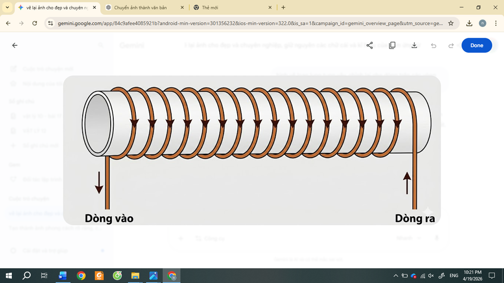

A. # từ trái sang phải.

B. từ trên xuống dưới.

C. từ dưới lên trên.

D. từ phải sang trái.

**Câu 3:** Một mạch kín phẳng có diện tích S đặt trong từ trường đều **B**. Biết vectơ pháp tuyến **n** của S hợp với vectơ cảm ứng từ **B** một góc α. Từ thông qua diện tích S là

A. # Φ = BS cosα.

B. Φ = B sinα.

C. Φ = S cosα.

D. Φ = BS sinα.

**Câu 4:** Khi ở nhà đang nghe đài phát thanh mà có ai đó cắm rút bếp điện, bạn là thì thường nghe thấy có tiếng lẹt xẹt trong loa vì

A. thời tiết xấu nên sóng bị nhiễu.

B. # việc cắm, rút khỏi mạng điện tạo sóng điện từ gây nhiễu âm thanh.

C. việc cắm, rút khỏi mạng điện tác động đến mạng điện trong nhà.

D. bếp điện, bàn là là những vật trực tiếp làm nhiễu âm thanh.

**Câu 5:** Hạt nhân Uranium có 92 proton và 143 notron kí hiệu nhân là

A. ${}_{92}^{235}U$

B. # ${}_{92}^{235}U$

C. ${}_{235}^{92}U$

D. ${}_{92}^{143}U$

**Câu 6:** So với hạt nhân ${}_{6}^{12}C$thì hạt nhân ${}_{27}^{56}Co$có nhiều hơn

A. 44 neutron và 21 proton.

B. # 23 neutron và 21 proton.

C. 44 neutron và 23 proton.

D. 23 neutron và 23 proton.

**Câu 7:** Cho phản ứng hạt nhân:${}_{Z}^{A}X +_{9}^{19}F \rightarrow_{2}^{4}He +_{8}^{16}O$*.* Hạt X là

A. alpha

B. neutron

C. doteri

D. # proton

**Câu 8:** Cho hạt nhân ${}_{3}^{6}Li$(Liti) có $m_{Li} = 6,0082$amu, biết $m_{p} = 1,0073$amu, $m_{n} = 1,0087$amu. Độ hụt khối của hạt nhân ${}_{3}^{6}Li$là

A. Δm = 0,398 amu

B. # Δm = 0,0398 amu

C. Δm = −0,398 amu

D. Δm = −0,0398 amu

A. 19,6 MeV/nucleon.

C. 7,0 MeV/nucleon.

D. 15,6 MeV/nucleon.

**Câu 10:** Kết luận nào về bản chất của các tia phóng xạ dưới đây là **không đúng**?

A. # Tia α, β, γ đều có chung bản chất là sóng điện từ có bước sóng khác nhau.

B. Tia α là dòng các hạt nhân nguyên tử ${}_{2}^{4}He$.

C. Tia β là dòng các hạt pôzitron.

D. Tia β là dòng các hạt electron.

**Câu 11:** Hình bên là đồ thị biểu diễn số hạt nhân còn lại của một chất phóng xạ theo thời gian t. Chu kì bán rã của chất phóng xạ là

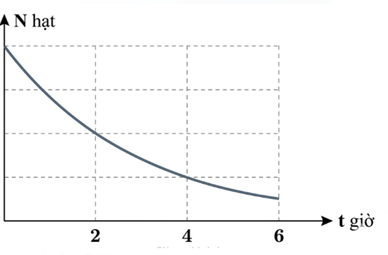

A. 1 giờ.

B. 4 giờ.

C. # 2 giờ.

D. 6 giờ.

**Câu 12:** Tại sao đồng vị phóng xạ ${}_{53}^{131}I$lại hiệu quả trong việc điều trị ung thư tuyến giáp?

A. Vì nó phát ra tia gamma tiêu diệt tế bào ung thư từ bên ngoài.

B. # Vì nó có khả năng tập trung cao trong tuyến giáp và phát ra bức xạ beta tiêu diệt tế bào ung thư.

C. Vì nó dễ dàng phân hủy thành các chất vô hại.

D. Vì nó có thời gian bán rã dài, kéo dài hiệu quả điều trị.

**Câu 13:** Một đoạn dây dẫn dài 2 cm nằm trong từ trường, dòng điện chạy qua có cường độ 1 A. Một nam châm tạo từ trường có cảm ứng từ 0,5 T và hợp với dây dẫn một góc $30^{\circ}$. Lực từ tác dụng lên dây dẫn có độ lớn là

A. $50 \cdot 10^{- 2}$N.

B. $10 \cdot 10^{- 2}$N.

C. $1,0 \cdot 10^{- 2}$N.

D. # $0,5 \cdot 10^{- 2}$N.

**Câu 14:** Chiếu 3 chùm tia thu được từ quá trình phóng xạ hạt nhân lần lượt qua tấm giấy, nhôm và chì như hình vẽ. Các tia 1, tia 2, tia 3, theo thứ tự lần lượt là:

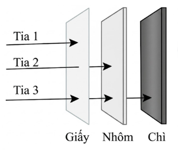

A.# tia α, tia β, tia γ.

B. tia β, tia γ, tia α.

C. tia γ, tia α, tia β.

D. tia β, tia α, tia γ.

**Câu 15:** Khi một hạt nhân ${}_{92}^{235}U$bị phân hạch tỏa ra năng lượng 200 MeV. Cho biết $N_{A} = 6,02 \cdot 10^{23}\text{ mol}^{- 1}$. Nếu 1 g ${}_{92}^{235}U$bị phân hạch hoàn toàn thì năng lượng tỏa ra xấp xỉ bằng

A. # $8,2 \cdot 10^{10}$J.

B. $5,1 \cdot 10^{10}$J.

C. $8,2 \cdot 10^{16}$J.

D. $5,1 \cdot 10^{16}$J.

**Câu 16:** Khi hạt nhân nguyên tử phóng xạ phát ra tia γ thì

A. Số proton giảm một, số neutron giảm một.

B. Số proton giảm một, số neutron tăng một.

C. # Số proton và neutron giữ nguyên.

D. Số proton tăng hai, số neutron giảm hai.

**Câu 17:** Trong không khí, tia phóng xạ nào sau đây có tốc độ nhỏ nhất?

A. Tia gamma (γ).

B. # Tia alpha (α).

C. Tia beta trừ (β⁻).

D. Tia beta cộng (β⁺).

**Câu 18:** Bộ phận chính của nhà máy điện hạt nhân là

A. # lò phản ứng hạt nhân.

B. đường vào của nước làm mát.

C. tháp làm mát.

D. bộ phận sinh hơi.

**Câu 1 (Đ/S):** Cho một khung dây dẫn kín đồng chất, cứng, hình chữ nhật ABCD có độ dài các cạnh là 30 cm và 20 cm. Biết khung dây có điện trở là $R = 0,5\Omega$. Khung dây dẫn được đặt trong từ trường đều sao cho cảm ứng từ B vuông góc với mặt phẳng khung dây. Ban đầu, cảm ứng từ có độ lớn $0,3\text{ }T$. Cho độ lớn cảm ứng từ tăng đều lên $0,6\text{ }T$trong khoảng thời gian $\Delta t = 0,02\text{ }s$.

a) # Độ lớn suất điện động cảm ứng tỉ lệ với tốc độ biến thiên của từ thông.

b) Dòng điện cảm ứng xuất hiện trong khung có chiều theo thứ tự A → B → C → D → A.

c) # Độ biến thiên từ thông qua khung dây dẫn có độ lớn là $0,018\text{ }Wb$.

d) Cường độ dòng điện cảm ứng chạy trong khung dây trong khoảng thời gian $\Delta t$nói trên là $1,2\text{ }A$.

**Câu 2 (Đ/S):** Hạt nhân Uranium có kí hiệu là ${}_{92}^{238}U$. Ta có các nhận định sau:

a) Nguyên tố Uranium nằm ở ô thứ 238 trong bảng hệ thống tuần hoàn.

b) Hạt nhân ${}_{92}^{238}U$có 92 proton và 146 nucleon.

c) # Bán kính hạt nhân ${}_{92}^{238}U$có thể được ước tính bằng công thức $R = 1,2 \cdot 10^{- 15} \cdot \sqrt[3]{A}\text{ }(m),\text{với }A = 238.$

d) Coi hạt nhân ${}_{92}^{238}U$có dạng hình cầu thì thể tích của nó là $1,7 \cdot 10^{- 42}\text{ }m^{3}$.

**Câu 3 (Đ/S):** Cho phản ứng hạt nhân: ${}_{7}^{14}N +_{2}^{4}He \rightarrow_{8}^{17}O +_{1}^{1}X\$ Cho biết khối lượng của các hạt nhân ${}^{14}N$, ${}^{4}He$, ${}^{17}O$và ${}^{1}H$. lần lượt là $m_{N} = 14,003$amu; $m_{He} = 4,0015$amu; $m_{O} = 16,999$amu; $m_{p} = 1,0073$amu. Lấy $1\text{ amu} = 931,5\text{ MeV}/c^{2}$.

a) # Hạt nhân X là ${}_{1}^{1}H$.

b) # Độ hụt khối của phản ứng được tính bởi công thức: $\Delta m = \left( m_{N} + m_{He} \right) - \left( m_{O} + m_{X} \right)$

c) # Nếu hạt nhân X là hạt ${}_{1}^{1}H$thì phản ứng trên thu năng lượng vì $\Delta m = - 0,0018\text{ amu}$.

d) # Năng lượng trao đổi từ phản ứng trên có độ lớn gần đúng là $2,68 \cdot 10^{- 13}\text{ J}$.

**Câu 4 (Đ/S):** Chất phóng xạ polonium ${}_{84}^{210}Po$phóng ra tia α và biến thành hạt nhân X theo phương trình: ${}_{84}^{210}Po \rightarrow \alpha + X\$. Biết chu kì bán rã của Polonium là 138 ngày, $N_{A} = 6,022 \cdot 10^{23}\text{ }\text{mol}^{- 1}$.

a) # Hạt nhân X là hạt nhân chì ${}_{82}^{206}Pb$.

b) Khối lượng hạt nhân X tạo ra bằng khối lượng hạt nhân Po đã phân rã.

c) # Ban đầu có 5 gam Polonium, độ phóng xạ ban đầu của Polonium là $8,3 \cdot 10^{14}\text{ Bq}$.

d) Ban đầu có 5 gam Polonium, khối lượng hạt X tạo thành sau 414 ngày là 0,708 gam.

**Câu 1 (Đ/S):** Cho một khung dây dẫn kín đồng chất, cứng, hình chữ nhật ABCD có diện tích $0,02\text{ }m^{2}$. Biết khung dây có điện trở là $R = 0,5\Omega$.

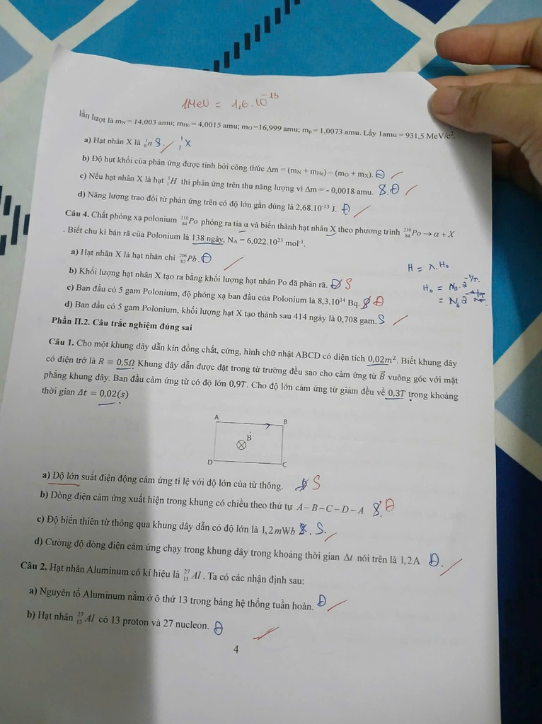

. Khung dây dẫn được đặt trong từ trường đều sao cho cảm ứng từ B vuông góc với mặt phẳng khung dây. Ban đầu cảm ứng từ có độ lớn $0,9\text{ }T$. Cho độ lớn cảm ứng từ giảm đều về $0,3\text{ }T$trong khoảng thời gian $\Delta t = 0,02\text{ }s$.

a) Độ lớn suất điện động cảm ứng tỉ lệ với độ lớn của từ thông.

b) # Dòng điện cảm ứng xuất hiện trong khung có chiều theo thứ tự A → B → C → D → A.

c) Độ biến thiên từ thông qua khung dây dẫn có độ lớn là $1,2\text{ }mWb$.

d) # Cường độ dòng điện cảm ứng chạy trong khung dây trong khoảng thời gian $\Delta t$nói trên là $1,2\text{ }A$.

**Câu 2 (Đ/S):** Hạt nhân Aluminum có kí hiệu là ${}_{13}^{27}Al$. Ta có các nhận định sau:

a) # Nguyên tố Aluminum nằm ở ô thứ 13 trong bảng hệ thống tuần hoàn.

b) # Hạt nhân ${}_{13}^{27}Al$có 13 proton và 27 nucleon.

c) Bán kính hạt nhân ${}_{13}^{27}Al$có thể được ước tính bằng công thức $R = 1,5 \cdot 10^{- 15} \cdot \sqrt[3]{A}\text{\:\,}(m),\text{với }A = 27.$  
d) # Coi hạt nhân ${}_{13}^{27}Al$có dạng hình cầu thì thể tích của nó là $1,95 \cdot 10^{- 43}\text{ }m^{3}$.

**Câu 3 (Đ/S):** Cho phản ứng hạt nhân: $X +_{4}^{9}Be \rightarrow_{2}^{4}He +_{3}^{6}Li\$ Cho biết khối lượng của các hạt nhân $X$, ${}^{9}Be$, ${}^{4}He$và ${}^{6}Li$lần lượt là: $m_{X} = 1,0073$amu; $m_{Be} = 9,0027$amu; $m_{He} = 4,0015$amu; $m_{Li} = 6,0135$amu. Lấy $1\text{ amu} = 931\text{ MeV}/c^{2}$.

a) # Hạt nhân X là ${}_{1}^{1}p$.

b) # Độ hụt khối của phản ứng được tính bởi công thức: $\Delta m = m_{X} + m_{Be} - (m_{He} + m_{Li})$  
c) # Phản ứng trên thu năng lượng vì $\Delta m = - 0,005\text{ amu}$.

d) Năng lượng trao đổi từ phản ứng trên có giá trị là $4,655\text{ MJ}$.

**Câu 1 (TLN):** Một khung dây dẫn quấn thành hình tròn bán kính vòng dây 15 cm gồm 200 vòng và mặt phẳng khung dây vuông góc với cảm ứng từ có độ lớn thay đổi từ $0,03\text{ }T$đến $0,12\text{ }T$trong $10\text{ }ms$. Độ lớn suất điện động cảm ứng trong khung dây bằng bao nhiêu Volt?  
*(Kết quả làm tròn đến phần nguyên).*

*# 127*

**Câu 2 (TLN)::** Khung dây kim loại phẳng có diện tích $S = 100\text{ }cm^{2}$, có $N = 500$vòng dây, quay đều với tốc độ $3000$vòng/phút quanh trục vuông góc với đường sức của một từ trường đều $B = 0,01\text{ }T$. Lấy $\pi = 3,14$. Suất điện động cảm ứng xuất hiện trong khung dây có giá trị hiệu dụng bằng bao nhiêu Volt?  
*(Kết quả làm tròn đến một chữ số thập phân).*

*# 11,1*

**Câu 3 (TLN)::** Một học sinh tự chế tạo một máy biến áp với dự tính số vòng dây ban đầu của cuộn sơ cấp và cuộn thứ cấp lần lượt là $N_{1} = 100$vòng và $N_{2} = 800$vòng. Nhưng trong quá trình quấn dây, học sinh đã quấn ngược một số vòng dây ở cuộn thứ cấp nên khi đặt vào hai đầu cuộn sơ cấp một điện áp $u_{1} = 20\cos(100\pi t)\text{\:\,}(V)\$ thì điện áp hiệu dụng ở hai đầu cuộn thứ cấp đo được là 99 V. Học sinh này đã quấn ngược bao nhiêu vòng dây?  
*(Kết quả làm tròn đến hàng đơn vị).*

*# 50*

[HD]  
**dùng điện áp hiệu dụng**

$U_{1} = \frac{20}{\sqrt{2}} \approx 14,14\text{ V;}$ Trong đề:$U_{2} = 99$V (đã là hiệu dụng) vì quấn ngược nên Bạn dùng: $\frac{U_{1}}{U_{2}} = \frac{N_{1}}{N_{2} - 2n}$ 🡪 $\frac{99}{14,14} = \frac{800 - 2n}{100}\ \ \ - - > \ 7 = \frac{800 - 2n}{100} \Rightarrow 800 - 2n = 700 \Rightarrow 2n = 100 \Rightarrow n = 50$

**Câu 4 (TLN)::** Tổng số proton và neutron có trong $59,50\text{ }g{}_{92}^{238}U$bằng $x \cdot 10^{25}$hạt. Giá trị $x$bằng bao nhiêu?  
Biết $N_{A} = 6,022 \cdot 10^{23}\text{ }mol^{- 1}$. *(Kết quả làm tròn đến hai chữ số thập phân).*

*# 3,58*

**Câu 5 (TLN)::** Cho một hạt neutron có động năng lớn đến bắn phá hạt nhân ${}_{92}^{235}U$đang đứng yên để tạo ra phản ứng phân hạch: ${}_{0}^{1}n +_{92}^{235}U \rightarrow_{38}^{94}Sr +_{54}^{140}Xe + x_{0}^{1}n$.  
Trong phản ứng phân hạch này, năng lượng của phản ứng được xác định bằng hiệu của năng lượng liên kết giữa các hạt nhân sản phẩm với các hạt nhân tham gia phản ứng. Biết năng lượng liên kết riêng của ${}_{92}^{235}U$là $7,58\,\text{MeV/nucleon},\ _{54}^{140}{Xe}\ là8,29\text{ MeV/nucleon }và\ của{}_{38}^{94}Sr\ là8,59\text{ MeV/nucleon}.\$Tính năng lượng của phản ứng theo đơn vị MeV. *(Kết quả làm tròn đến phần nguyên).*

*# 187*

[HD]  
theo gợi ý của đề thì Năng lượng phản ứng $Q$ được tính bằng hiệu của tổng năng lượng liên kết sản phẩm trừ tổng năng lượng liên kết tham gia: $Q = (140 \cdot 8,29 + 94 \cdot 8,59) - (235 \cdot 7,58)$ = 187

**Câu 6 (TLN)::** Chất phóng xạ Polonium ${}_{84}^{210}Po$phát ra tia α và biến đổi thành chì. Cho chu kì bán rã của Polonium là $138,4$ngày. Ban đầu có một mẫu Polonium nguyên chất, sau khoảng thời gian $t$(ngày) thì tỉ số giữa khối lượng chì sinh ra và khối lượng Polonium còn lại trong mẫu là $20,25$. Coi khối lượng nguyên tử bằng khối lượng hạt nhân của nguyên tử đó (tính theo đơn vị amu). Giá trị của $t$là bao nhiêu?  
*(Kết quả làm tròn đến phần nguyên).*

*# 614*

**Câu 1** **(TLN)::** Một khung dây dẫn quấn thành hình tròn đường kính vòng dây 15 cm gồm 100 vòng và mặt phẳng khung dây vuông góc với cảm ứng từ có độ lớn thay đổi từ $0,3\text{ }T$đến $0,12\text{ }T$trong $10\text{ }ms$. Độ lớn suất điện động cảm ứng trong khung dây bằng bao nhiêu Volt? *(Kết quả làm tròn đến chữ số thập phân thứ nhất).*

# 31,8

**Câu 2 (TLN)::** Khung dây kim loại phẳng có diện tích $S = 250\text{ }cm^{2}$, có $N = 100$vòng dây, quay đều với tốc độ $3600$vòng/phút quanh trục vuông góc với đường sức của một từ trường đều $B = 0,05\text{ }T$. Lấy $\pi = 3,14$. Suất điện động cảm ứng xuất hiện trong khung dây có giá trị hiệu dụng bằng bao nhiêu Volt? *(Kết quả làm tròn đến một chữ số thập phân).*

# 33,3

**Câu 3 (TLN)::** Một học sinh tự chế tạo một máy biến áp với dự tính số vòng dây ban đầu của cuộn sơ cấp và cuộn thứ cấp lần lượt là $N_{1} = 500$vòng và $N_{2} = 80$vòng. Nhưng trong quá trình quấn dây, học sinh đã quấn ngược một số vòng dây ở cuộn sơ cấp nên khi đặt vào hai đầu cuộn sơ cấp một điện áp $u_{1} = 200\cos(100\pi t)\text{\:\,}(V)$

thì điện áp hiệu dụng ở hai đầu cuộn thứ cấp đo được là $24\text{ }V$. Học sinh này đã quấn ngược bao nhiêu vòng dây? *(Kết quả làm tròn đến hàng đơn vị).*

# 14

[HD]  
$U_{1}\, = \,\frac{200}{\sqrt{2}}\,\text{ V}.\, Tỉsố:\frac{U_{1}}{U_{2}} = \frac{500 - 2n}{80} = \frac{200\text{/}\sqrt{2}}{24} \approx .$5,892 🡪 n gần bằng 14

**Câu 4 (TLN):** Tổng số neutron có trong $119\text{ }g{}_{92}^{235}U$bằng $x \cdot 10^{25}$hạt. Giá trị $x$bằng bao nhiêu? Biết $N_{A} = 6,022 \cdot 10^{23}\text{ }mol^{- 1}$. *(Kết quả làm tròn đến hai chữ số thập phân).*

# 4,36

**Câu 5 (TLN):** Hạt nhân ${}_{92}^{235}U$hấp thụ một neutron nhiệt rồi vỡ ra thành hai hạt nhân ${}_{56}^{141}Ba\,\ \,\text{và}\ _{36}^{93}{Kr}\ \$ kèm theo giải phóng một số hạt neutron mới theo phương trình: ${}_{92}^{235}U +_{0}^{1}n \rightarrow_{56}^{141}Ba +_{36}^{93}Kr + k_{0}^{1}n\ \$Trong phản ứng phân hạch này, năng lượng của phản ứng được xác định bằng hiệu của năng lượng liên kết giữa các hạt nhân sản phẩm với các hạt nhân tham gia phản ứng.  
Biết năng lượng liên kết riêng của ${}_{92}^{235}U$là $7,62\text{ MeV/nucleon}$, của ${}_{56}^{141}Ba$là $8,19\text{ MeV/nucleon}$và của ${}_{36}^{93}Kr$là $8,58\text{ MeV/nucleon}$. Tính năng lượng của phản ứng theo đơn vị MeV. *(Kết quả làm tròn đến phần nguyên).*

*# 162*

[HD]  
$Q = (141 \cdot 8,19 + 93 \cdot 8,58) - (235 \cdot 7,62)$ = 162,03 Mev

**Câu 1 (TLN):** Một đoạn dây dẫn dài $1,5\text{ m}$mang dòng điện $10\text{ A}$, đặt vuông góc trong một từ trường đều có độ lớn cảm ứng từ $1,2\text{ T}$. Lực từ tác dụng lên đoạn dây có độ lớn bằng bao nhiêu?

# 18

**Câu 2 (TLN)::** Một khung dây dẫn kín có diện tích $20\text{ }\text{cm}^{2}$, quay đều trong từ trường đều có cảm ứng từ bằng $0,02\text{ T}$. Tính độ lớn suất điện động cảm ứng (theo đơn vị mV) sinh ra trong vòng dây khi góc hợp bởi vectơ cảm ứng từ và vectơ pháp tuyến của mặt phẳng khung dây thay đổi từ $30^{\circ}$đến $60^{\circ}$trong khoảng thời gian $0,01\text{ s}$? (Kết quả làm tròn đến 2 chữ số thập phân)

# 1,46

[HD]  
Diện tích: $S = 20\text{ cm}^{2} = 20 \cdot 10^{- 4} = 2 \cdot 10^{- 3}\text{ m}^{2}\ \$Độ biến thiên từ thông: $\Delta\Phi = BS(\cos 30^{\circ} - \cos 60^{\circ})$ 🡪 $\Delta\Phi = 0,02 \cdot 2 \cdot 10^{- 3} \cdot \left( \frac{\sqrt{3}}{2}-\frac{1}{2} \right) \approx 1,464 \times 10^{- 5}\text{ Wb}$ 🡪 Suất điện động cảm ứng trung bình: $e = \frac{\mid \Delta\Phi \mid}{\Delta t} = \frac{1,464 \times 10^{- 5}}{0,01} = 1,464 \times 10^{- 3}\text{ V}$ 🡪 Đổi ra mV: $e \approx 1,46\text{ mV}$

**Câu 3 (TLN)::** Năng lượng liên kết riêng của ${}^{235}\text{U}$là $7,7\text{ MeV}/\text{nucleon}$. Biết khối lượng proton và neutron là $m_{p} = 1,0073\text{ amu},\text{ }m_{n} = 1,0087\text{ amu},\text{ }1\text{ amu} = 931,5\text{ MeV}/c^{2}$. Độ hụt khối của hạt nhân ${}^{235}\text{U}$bằng bao nhiêu amu? (Kết quả làm tròn đến chữ số phần trăm)

# 1,94

**Câu 4 (TLN)::** Đồng vị ${}^{238}\text{U}$phân rã qua một chuỗi phân rã phóng xạ $\alpha$và $\beta$biến thành hạt nhân bền ${}^{206}\text{Pb}$. Biết chu kì bán rã của ${}^{238}\text{U}$là $4,47 \cdot 10^{9}$năm. Một khối đá được phát hiện chứa $46,97\text{ mg}{\text{ }\text{ }\text{ }\text{ }\text{ }\text{ }\text{ }\text{ }}^{238}\text{U}$và $23,15\text{ mg}{\text{ }\text{ }\text{ }\text{ }\text{ }\text{ }\text{ }\text{ }}^{206}\text{Pb}$. Giả sử khối đá khi mới hình thành không chứa nguyên tố chì và tất cả lượng chì có trong đó đều là sản phẩm phân rã của ${}^{238}\text{U}$. Tuổi của khối đá đó là bao nhiêu tỉ năm? (Kết quả làm tròn đến chữ số phần trăm)

# 2,91

[HD]  
Khối lượng chì (m<sub>con</sub>) tạo thành là do urani phân rã . 🡪 Số hạt Pb tạo thành tỉ lệ với số hạt U đã phân rã: Ncon = ∆N 🡪 m<sub>con</sub>/A<sub>con</sub> = ∆m/A<sub>mẹ</sub> 🡪 $m_{Pb} = \mathrm{\Delta}m\frac{206}{238}$ 🡪 Ta có:$\ mU = m_{0}\text{ }2^{- t/T}\ \$Vì phần U đã phân rã thành Pb nên:$m_{Pb} = m_{0}\left( 1-2^{- t/T} \right)\frac{206}{238}\$🡪 Lập tỉ số: $\frac{m_{Pb}}{m_{U}} = \frac{m_{0}(1 - 2^{- t/T})\frac{206}{238}}{m_{0}\text{ }2^{- t/T}}$ 🡪 giải pt tìm t

**Câu 5 (TLN)::** Ban đầu một mẫu chất phóng xạ nguyên chất có khối lượng $m_{0}$, chu kì bán rã của chất này là $3,8$ngày. Sau $15,2$ngày khối lượng của chất phóng xạ đó còn lại là $2,24\text{ gam}$. Khối lượng $m_{0}$là bao nhiêu? (Kết quả làm tròn đến chữ số hàng phần chục)

# 35,8

**Câu 6 (TLN)::** Biết khối lượng của proton, neutron, hạt nhân ${}^{16}\text{O}$lần lượt là $m_{p} = 1,0073\text{ u},\text{ }m_{n} = 1,0087\text{ u},\text{ }m = 15,9904\text{ u}$. Năng lượng liên kết của hạt nhân ${}^{16}\text{O}$bằng bao nhiêu MeV? (Kết quả làm tròn đến chữ số hàng đơn vị)

# 128

**Câu 1.** Đường sức từ không có đặc điểm nào sau đây?

A. Qua mỗi điểm trong không gian chỉ vẽ được một đường sức từ.

B. # Các đường sức từ là những đường cong không khép kín.

C. Đối với một nam châm, quy ước chiều đường sức từ đi ra từ cực Bắc và đi vào cực Nam của nam châm.

D. Quy ước về các đường sức từ mau ở nơi từ trường mạnh, thưa ở nơi từ trường yếu.

**Câu 2.** Phát biểu nào sau đây là sai? Lực từ tác dụng lên một đoạn dây có dòng điện đặt trong từ trường đều tỉ lệ với

A. cường độ dòng điện trong đoạn dây.

B. chiều dài của đoạn dây.

C. # sin của góc hợp bởi đoạn dây và đường sức từ.

D. cảm ứng từ tại nơi đặt đoạn dây.

**Câu 3.** Một khung dây diện tích S đặt trong từ trường đều có cảm ứng từ B, **góc giữa vectơ cảm ứng từ và mặt phẳng khung dây** là α. Từ thông Φ qua khung dây được tính theo công thức

A. # Φ = BS.sinα.

B. Φ = BS.tanα.

C. Φ = BS.cosα.

D. Φ = BS.cotanα.

**Câu 4.** Máy phát điện xoay chiều có khung dây quay hoặc có nam châm quay hoạt động dựa trên

A. tác dụng quang của dòng điện.

B. tác dụng nhiệt của dòng điện.

C. # hiện tượng cảm ứng điện từ.

D. tác dụng sinh lí của dòng điện.

**Câu 5.** Một dòng điện xoay chiều i có cường độ cực đại I₀ biến thiên theo thời gian t với tần số góc ω, pha ban đầu φᵢ. Biểu thức của i là

A. # i = I₀cos(ωt + φᵢ).

B. i = ωI₀t + φᵢ.

C. i = I₀cos(ωt² + φᵢ).

D. i = I₀ωt² + φᵢ.

**Câu 6.** Điện áp tức thời giữa hai đầu đoạn mạch điện xoay chiều là u = 311cos100πt (V). Giá trị hiệu dụng của điện áp đó là

A. 311 V.

B. # 220 V.

C. 156 V.

D. 440 V.

**Câu 7.** Nhận định nào sau đây là đúng khi nói về máy biến áp?

A. # Máy biến áp là thiết bị biến đổi điện áp xoay chiều nhưng không làm thay đổi tần số dòng điện.

B. Máy biến áp là thiết bị biến đổi điện áp xoay chiều cả về độ lớn và tần số của dòng điện.

C. Máy biến áp là thiết bị không tiêu thụ điện năng, chỉ chuyển hóa điện áp của dòng điện.

D. Máy biến áp là thiết bị hoạt động dựa trên hiện tượng cảm ứng điện từ có phần lõi sắt là nam châm vĩnh cửu.

**Câu 8.** Phát biểu nào sau đây là đúng khi nói về sóng điện từ?

A. Sóng điện từ là sóng dọc, truyền được trong chân không.

B. # Sóng điện từ là sóng ngang, truyền được trong chân không.

C. Sóng điện từ là sóng dọc, không truyền được trong chân không.

D. Sóng điện từ là sóng ngang, không truyền được trong chân không.

**Câu 9.** Các hạt nhân đồng vị là những hạt nhân có

A. cùng số neutron nhưng số nucleon khác nhau.

B. cùng số neutron và cùng số proton.

C. # cùng số proton nhưng số neutron khác nhau.

D. cùng số nucleon nhưng số proton khác nhau.

**Câu 10.** Hạt nhân nguyên tử ${}_{Z}^{A}X$được cấu tạo gồm

A. Z proton và (A – Z) nucleon.

B. Z proton và A neutron.

C. # Z proton và (A – Z) neutron.

D. Z proton và (A + Z) neutron.

**Câu 11.** Trong nguyên tử trung hòa của đồng vị phóng xạ ${}_{90}^{210}Th$có

A. 90 electron, tổng số proton và electron bằng 210.

B. # 90 proton, tổng số neutron và electron bằng 210.

C. 90 neutron, tổng số neutron và electron bằng 210.

D. 90 proton, tổng số proton và electron bằng 210.

**Câu 12.** Phát biểu nào sau đây *không đúng* khi nói về phản ứng hạt nhân thu năng lượng?

A. Tổng động năng của các hạt trước phản ứng lớn hơn tổng động năng của các hạt sau phản ứng.

B. Tổng năng lượng nghỉ trước phản ứng nhỏ hơn tổng năng lượng nghỉ sau phản ứng.

C. # Các hạt nhân sinh ra bền vững hơn các hạt nhân tham gia trước phản ứng.

D. Tổng khối lượng nghỉ các hạt nhân sau phản ứng lớn hơn tổng khối lượng nghỉ các hạt trước phản ứng.

**Câu 13.** Phản ứng hạt nhân nào sau đây không phải là phản ứng nhiệt hạch?

A. ${}_{1}^{1}H +_{1}^{2}H \rightarrow_{2}^{4}He$

B. ${}_{1}^{2}H +_{1}^{2}H \rightarrow_{2}^{4}He$

C. # ${}_{84}^{210}Po \rightarrow_{2}^{4}He +_{82}^{206}Pb$

D. ${}_{1}^{2}H +_{1}^{3}H \rightarrow_{2}^{4}He +_{0}^{1}n$

**Câu 14.** Trong các hạt nhân: ${}_{2}^{4}He$, ${}_{3}^{7}Li$, ${}^{5}6_{26}Fe$và ${}_{92}^{235}U$, hạt nhân bền vững nhất là

A. ${}_{92}^{235}U$

B. #${}_{26}^{56}Fe$

C. ${}_{3}^{7}Li$

D. ${}_{2}^{4}He$

**Câu 15.** Kết luận nào về bản chất của các tia phóng xạ dưới đây là *không đúng*?

A. # Các tia α, β, γ đều có chung bản chất là sóng điện từ nhưng có bước sóng khác nhau.

B. Tia α là dòng các hạt nhân nguyên tử ${}_{2}^{4}He$.

C. Tia β⁺ là dòng các hạt positron.

D. Tia β⁻ là dòng các hạt electron.

**Câu 16:** Cường độ dòng điện trong một đoạn mạch có biểu thức $i = 6\sqrt{2}\cos(100\pi t - 2\pi/3)$(A). Tại thời điểm $t = 0$, giá trị của $i$là

A. $3\sqrt{6}$(A).

B. $- 3\sqrt{6}$(A).

C. # $- 3\sqrt{2}$(A).

D. $3\sqrt{2}$(A).

**Câu 17:** Cho khối lượng của proton, neutron; $\,_{18}^{40}Ar\,,\ \,_{3}^{6}Li$ lần lượt là $1,0073$amu; $1,0087$amu; $39,9525$amu; $6,0145$amu và $1$amu $= 931,5$MeV/$c^{2}$. So với năng lượng liên kết riêng của hạt nhân $\,_{3}^{6}Li$ thì năng lượng liên kết riêng của hạt nhân $\,_{18}^{40}Ar$

A. nhỏ hơn một lượng là 3,42 MeV.

B. nhỏ hơn một lượng là 5,20 MeV.

C. lớn hơn một lượng là 5,20 MeV.

D. # lớn hơn một lượng là 3,42 MeV.

A. $12,04 \cdot 10^{23}$.

C. $6,02 \cdot 10^{23}$.

D. $3,01 \cdot 10^{23}$.

**Câu 1 (Đ/S):** Suất điện động trong một vòng dây có biểu thức $e = 2\sqrt{2}\cos\left( 100\pi t+\frac{\pi}{4} \right)\text{ V})\ \$

a) # Suất điện động hiệu dụng bằng 2 V.

b) # Tần số góc của suất điện động này là $100\pi$(rad/s).

c) Từ thông cực đại xuyên qua vòng dây này có giá trị $\frac{1}{50\pi}$Wb.

d) Tại thời điểm $t = 0,25$s, suất điện động có giá trị là $- \sqrt{2}$V.

**Câu 2 (Đ/S):** Nhiều nghiên cứu đã chứng minh rằng trong thuốc lá có chứa Polonium và chì. Đồng vị ${}_{84}^{210}Po$ phóng xạ $\alpha$và biến đổi thành hạt nhân chì bền, chu kì bán rã là 140 ngày. Ban đầu, một phòng nghiên cứu về biến đổi gen do${}_{84}^{210}Po$ gây ra đã nhận được mẫu thí nghiệm có 20 g Po, trong mẫu thí nghiệm đó không chứa chất phóng xạ khác.

a) # Phương trình phóng xạ là ${}_{84}^{210}Po \rightarrow \,_{2}^{4}{He}\ + \,_{82}^{206}Pb$

b) # Sau 140 ngày, khối lượng Po còn lại trong mẫu thí nghiệm là 10 g.

c) # Sau 140 ngày, khối lượng Pb được tạo ra trong mẫu thí nghiệm **là 9,8 g (kết quả lấy đến 2 chữ số có nghĩa).**

d) # Để khối lượng Po trong mẫu thí nghiệm bị phân rã là 18 g thì cần thời gian khoảng 465 ngày.

**Câu 3 (Đ/S):** Tổng hợp hạt nhân heli $\,_{2}^{4}He$ từ phản ứng hạt nhân ${}_{1}^{1}H + \,_{3}^{7}Li \rightarrow \,_{2}^{4}He + X\$Mỗi phản ứng trên tỏa năng lượng 17,3 MeV. Cho biết số Avogadro bằng $6,022 \cdot 10^{23}$hạt/mol.

a) Hạt $X$là $\,_{2}^{3}He.$

b) Số hạt $\,_{2}^{4}He$ sinh ra bằng số phản ứng tổng hợp hạt nhân heli.

c) Năng lượng tỏa ra khi tổng hợp được 0,5 mol heli là $5,2 \cdot 10^{24}$MeV.

d) Nếu số mol $\,_{2}^{4}He$bằng 0,3 mol thì số hạt nhân là $3,011 \cdot 10^{23}$hạt.

**Câu 4 (Đ/S):** Từ trường đều giữa hai cực của nam châm hình chữ U bằng $0,075$T. Một cuộn dây nhỏ có tiết diện thẳng $4,8\text{ }\text{cm}^{2}$ có 20 vòng dây được đặt sao cho mặt phẳng của nó vuông góc với từ trường. Cuộn dây được rút ra khỏi từ trường trong $0,3$s.

a) # Độ biến thiên từ thông trong mỗi vòng dây khi cuộn dây được rút ra khỏi từ trường có giá trị là $3,6 \cdot 10^{- 5}\text{ Wb}$

b) Suất điện động cảm ứng trung bình trong cuộn dây là $2 \cdot 10^{- 3}\text{ V}$.

c) # Từ thông mỗi vòng của cuộn dây khi nó nằm giữa hai cực của nam châm là $3,6 \cdot 10^{- 5}\text{ Wb}$.

d) Góc hợp bởi giữa vectơ từ trường và vectơ pháp tuyến bằng $90^{\circ}$.